# WUM PD2

Adam Rydelek

18 - 03 - 2019

# 1 Wprowadzenie

Dane, które wybrałem do analizy pochodzą ze zbioru Compass. Zostały one poddane, w ramach pracy nad projektem, obróbce, dzięki której powstał zbiór na którym będę dzisiaj operował. Poniżej znajduje się tabelka z ilością unikalnych wartości poszczególnych zmiennych kategorycznych.

```r
apply(datay, 2, function(x) length(unique(x)))
```

```
##              X1           first            last             dob
##           10331            3669            5331            7164
##   custody_count             sex             age         age_cat
##              12               2              65               3
##            race   juv_fel_count  juv_misd_count juv_other_count
##               6              12              11              12
##    priors_count       c_jail_in      c_jail_out c_charge_degree
##              39             796             901              15
##   c_charge_desc        is_recid       bust_date       jail_time
##             514               2            1163             392
##     custody_sum           month
##             908              13
```

Można więc zauważyć, że w tej ramce danych są zmienne kategoryczne z bardzo dużą liczą unikalnych danych. Na początek odrzucimy te kolumny, które nie powinny wpływać na model, czyli: `first` i `last`. Usuniemy z ramki danych też: `c_jail_in`, `c_jail_out`, `bust_date`, `dob`, aby na razie nie zajmować się datami. Można jednak zauważyć, że zmienna `c_charge_description` została i ma ona aż **514** unikalnych wartości.

## 1.1 Sprawdzenie wydajności bez kodowania zmiennych

Aby mieć punkt zaczepienia zrobimy model opierający się na powyższej ramce z usuniętymi kolumnami wymionymi powyżej. Został on podzielony na 3 części: część uczącą (60%), walidacyjną (20%) i testową (20%). Sprawdzimy, jak poradzi sobie z problemem wyznaczenia wartości `is_recid` na zbiorze testowym.

```r
spec = c(train = .6, test = .2, validate = .2)

g = sample(cut(
  seq(nrow(datay)),
  nrow(datay)*cumsum(c(0,spec)),
  labels = names(spec)
))

datastock <- select(datay, -c(c_jail_in, c_jail_out, bust_date, first, last, dob))
resS = split(datastock, g)
train3 <- resS$train
test3 <- resS$test
train3[sapply(train3, is.character)] <- lapply(train3[sapply(train3, is.character)],
                                       as.factor)
test3[sapply(test3, is.character)] <- lapply(test3[sapply(test3, is.character)],
                                               as.factor)

classif_task <- makeClassifTask(id = "task", data = train3, target = "is_recid")
classif_lrn <- makeLearner("classif.gbm", predict.type = "prob")

model1 <- mlr::train(classif_lrn, classif_task)
```

```
## Distribution not specified, assuming bernoulli ...
```

```r
predict1 <- predict(model1, newdata = test3, type='response')

confusionMatrix(factor(predict1$data$response), factor(test3$is_recid))
```

```
## Confusion Matrix and Statistics
##
##           Reference
## Prediction    0    1
##          0 1224  382
##          1  141  319
##
##                Accuracy : 0.7469
##                  95% CI : (0.7275, 0.7655)
##     No Information Rate : 0.6607
##     P-Value [Acc > NIR] : < 2.2e-16
##
##                   Kappa : 0.3839
##  Mcnemar's Test P-Value : < 2.2e-16
##
##             Sensitivity : 0.8967
##             Specificity : 0.4551
##          Pos Pred Value : 0.7621
##          Neg Pred Value : 0.6935
##              Prevalence : 0.6607
##          Detection Rate : 0.5924
##    Detection Prevalence : 0.7773
##       Balanced Accuracy : 0.6759
##
##        'Positive' Class : 0
##
```

Otrzymane wyniki to nasz punkt wyjścia, zobaczymy, czy uda się go poprawić.

# 2 Impact Encoding

Teraz spróbujemy za pomocą pakietu `vtreat` ulepszyć nasz model, dzięki zastosowaniu **impact encoding** na ramce danych, która zażegna nasz problem za dużej liczby unikalnych wartości zmiennych kategorycznych. Wykonam to za pomocą funkcji *designTreatments* i wybiorę odpowiednie jej kolumny odpowiadające za impact encoding.

## 2.1 Sprawdzenie wydajności Impact Encoding

```r
dataimpact <- select(datay, -c(c_jail_in, c_jail_out, bust_date, first, last, dob))
res = split(dataimpact, g)
train2 <- res$train
calibration2 <- res$validate
test2 <- res$test

pruneSig <- 1/ncol(train2)

treatments <- designTreatmentsN(calibration2, varlist=colnames(train2), outcome="is_recid", verbose=FALSE)
scoreFrame <- treatments$scoreFrame
vars <- scoreFrame$varName[(scoreFrame$code %in% c("catN", "clean"))]
dTrainTreated <- prepare(treatments,train2,pruneSig=pruneSig, varRestriction = vars)

classif_task_t <- makeClassifTask(id = "task", data = dTrainTreated, target = "is_recid")
classif_lrn_t <- makeLearner("classif.gbm", predict.type = "prob")

dTestTreated <- prepare(treatments,test2,
                        pruneSig=pruneSig, varRestriction = vars)

model2 <- mlr::train(classif_lrn_t, classif_task_t)
```

```
## Distribution not specified, assuming bernoulli ...
```

```r
predict2 <- predict(model2, newdata = dTestTreated, type='response')

confusionMatrix(factor(predict2$data$response), factor(dTestTreated$is_recid))
```

```
## Confusion Matrix and Statistics
##
##           Reference
## Prediction    0    1
##          0 1266  395
##          1   99  306
##
##                Accuracy : 0.7609
##                  95% CI : (0.7419, 0.7791)
##     No Information Rate : 0.6607
##     P-Value [Acc > NIR] : < 2.2e-16
##
##                   Kappa : 0.4057
##  Mcnemar's Test P-Value : < 2.2e-16
##
##             Sensitivity : 0.9275
##             Specificity : 0.4365
##          Pos Pred Value : 0.7622
##          Neg Pred Value : 0.7556
##              Prevalence : 0.6607
##          Detection Rate : 0.6128
##    Detection Prevalence : 0.8040
##       Balanced Accuracy : 0.6820
##
##        'Positive' Class : 0
##
```

Można zauważyć poprawę względem modelu bez kodowania. Accuracy podniosło się o ponad **0.014**, a Sensitivity o **0.031**.

# 3 One Hot Encoding

Sprawdzimy również sposób kodowania: **One Hot Encoding**, który rozbija zmienne kategoryczne na nowe kolumny im odpowiadające, które zawierają wartości 0 i 1 , tak zwane **dummy variables**. Do otrzymania tych zmiennych wykorzystam funkcję *dummyVars* z pakietu `dplyr`, chociaż da się to również zrobić za pomocą biblioteki `vtreat`. Jednak jako, że zmienna c_charge_desc ma aż 514 unikalnych wartości na początku zmniejszyłem ich liczbę do 50 za pomocą funkcji *fct_lump* z pakietu `forcats`, która zmniejsza liczbę unikalnych wartości patrząc na ich rzadkość.

## 3.1 Sprawdzenie wydajności One Hot Encoding

```r
datarare <- datay
datarare$c_charge_desc <- fct_lump(datarare$c_charge_desc, 50)
datarare <- select(datarare, -c(c_jail_in, c_jail_out, bust_date, first, last, dob))
dmyT <- dummyVars(" ~ .", data = datarare)
dmydata <- data.frame(predict(dmyT, newdata = datarare))
res = split(dmydata, g)
trainOne <- res$train
calibrationOne <- res$validate
testOne <- res$test

trainOne$is_recid <- factor(trainOne$is_recid)
testOne$is_recid <- factor(testOne$is_recid)

classif_task_t <- makeClassifTask(id = "task", data = trainOne, target = "is_recid")
classif_lrn_t <- makeLearner("classif.gbm", predict.type = "prob")

model3 <- mlr::train(classif_lrn_t, classif_task_t)
```

```
## Distribution not specified, assuming bernoulli ...
```

```r
predict3 <- predict(model3, newdata = testOne, type='response')

confusionMatrix(factor(predict3$data$response), factor(dTestTreated$is_recid))
```

```
## Confusion Matrix and Statistics
##
##           Reference
## Prediction    0    1
##          0 1278  397
##          1   87  304
##
##                Accuracy : 0.7657
##                  95% CI : (0.7469, 0.7838)
##     No Information Rate : 0.6607
##     P-Value [Acc > NIR] : < 2.2e-16
##
##                   Kappa : 0.4145
##  Mcnemar's Test P-Value : < 2.2e-16
##
##             Sensitivity : 0.9363
##             Specificity : 0.4337
##          Pos Pred Value : 0.7630
##          Neg Pred Value : 0.7775
##              Prevalence : 0.6607
##          Detection Rate : 0.6186
##    Detection Prevalence : 0.8107
##       Balanced Accuracy : 0.6850
##
##        'Positive' Class : 0
##
```

Można zauważyć, że jest on również definitywnie lepszy od modelu bez żadnego kodowania, a nawet trochę poprawił porzedni model z Impact Encoding. Liczba poprawnie odgadniętych przypadków recydywy (“True Positives”) zmalała, natomiast liczba poprawnie odgadniętych przypadków braku recydywy wzrosła (“True Negative”).

# 4 Podsumowanie

Podsumowując można zauważyć, że przeprowadzone kodowanie zmiennych dało oczekiwany rezultat, mianowicie poprawiło działanie modelu, jednak zmiany nie były drastyczne. Może być to spowodowane tym, że learner sam w sobie koduje zmienne kategoryczne w pewien sposób i robi to całkiem nieźle, dlatego punkt wyjścia był już dobrym wynikiem. Na koniec tabelka podsumowująca kilka głównych miar na przestrzeni trzech modeli.

|  | No Encoding | Impact Encoding | One Hot Encoding |
| --- | --- | --- | --- |
| Accuracy | 0.7469 | 0.7609 | 0.7657 |
| Sensitivity | 0.8967 | 0.9275 | 0.9363 |

Oraz trzy krzywe ROC dla poszczególnych modeli:

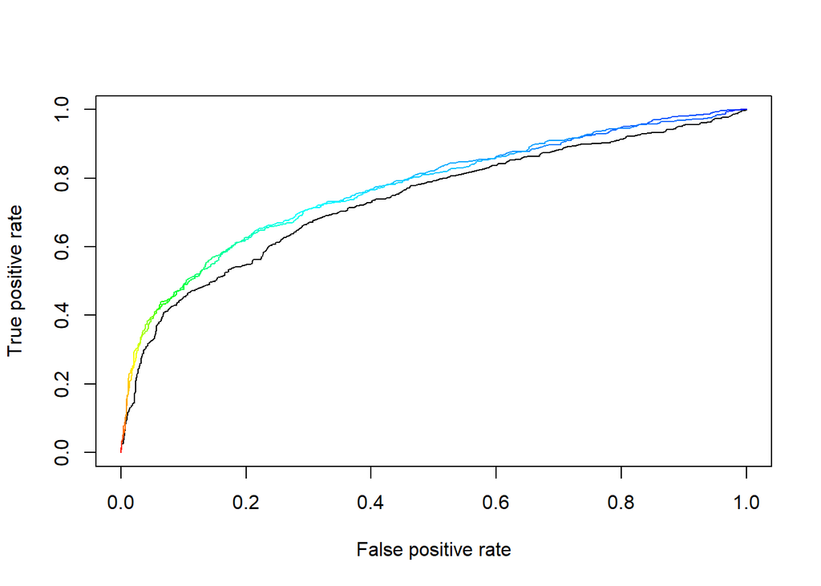

```r
library(ROCR)
pred <- ROCR::prediction(predict1$data$prob.1,as.numeric(test3$is_recid))
pred1 <- ROCR::prediction(predict2$data$prob.1,as.numeric(dTestTreated$is_recid))
pred2 <- ROCR::prediction(predict3$data$prob.1,as.numeric(testOne$is_recid))

perf <- performance( pred, "tpr", "fpr" )
perf2 <- performance( pred1, "tpr", "fpr" )
perf3 <- performance( pred2, "tpr", "fpr" )

plot( perf, colorize = FALSE)
plot(perf2, add = TRUE, colorize = TRUE)
plot(perf3, add = TRUE, colorize = TRUE)
```

Krzywa czarna to krzywa ROC modelu bez żadnego kodowania i widać, że pole pod nią jest najmniejsze, dwie kolorowe krzywe oznaczające Impact Encoding i One Hot Encoding są bardzo zbliżone sobie i bardzo ciężko określić, która ma większe pole.